# Part 1 Data Preparation

I used Safe Software FME to perform the data cleansing. I imported the CSV file, performed a "Tester" to ensure the Lat/Longs were correct. I set the values of >= 39 for Lat and >=80 for Long. The next transformer I used was a DuplicateFilter to filter out duplicate lat and long key attributes. Next I ran an AttributeFilter to split local_dtm into a day and time. I ran it through another AttributeFilter to split out the Day, Month and Year. Next the process went through an AttributeManager where I set the Date to "@Value(Date{1})-@Value(Date{0})-20@Value(Date{2})" i.e, MAY-19-2017. Next the process trims the ":" in front of the Time field. I run a TestFilter to extract the unique "trip_nb" values (16). Next I perform a DateTimeConvertor to put the processed DateTime field into a format that can be used for Calculating Motion Tracks in ArcGIS Pro ("2017-05-19 07:33:59"). Next I run another DuplicatFilter to remove duplicate DateTimes so the geoprocessing tool in ArcGIS Pro will not error.

[figure not shown]

In ArcGIS Pro, I brought in the output CSV from FME. I ran a process to Display X/Ys from the dataset into the correct coordinate system in the Map. I used the Calculate Motion Statistic toolset through GeoAnalytics Desktop geoprocessing tools. This allows the user to calculate motion statistics such as Acceleration, Speed, Distance, Idling, Bearing, and many others. The tool allows the user to set certain thresholds on idle distance, idle time, and set a track history window consisting of a set-amount of previous points to use in the analysis.

[figure not shown]

```python
import pandas as pd
df = pd.read_csv('loc_stats_prod.csv')
df.head()
```

|  | OID_ | OBJECTID | trip_nb | BrakingCount | AccelerationCount | latitude | longitude | Date | Time | DateTime | ... | Acceleration | MinAcceleration | MaxAcceleration | AvgAcceleration | BrakingCount.1 | AccelerationCount.1 | Idling | TotIdleTime | PctIdleTime | DATE1 |
| --- | --- | --- | --- | --- | --- | --- | --- | --- | --- | --- | --- | --- | --- | --- | --- | --- | --- | --- | --- | --- | --- |
| 0 | 2425 | 3837 | 1 | 0 | 1 | 40.037952 | -83.071342 | 5/19/2017 0:00 | 7:33:59 | 5/19/2017 7:33 | ... | NaN | NaN | NaN | NaN | 0 | 1 | NaN | NaN | NaN | 5/19/2017 7:33 |
| 1 | 2426 | 3838 | 1 | 0 | 1 | 40.038181 | -83.071274 | 5/19/2017 0:00 | 7:34:01 | 5/19/2017 7:34 | ... | NaN | NaN | NaN | NaN | 0 | 1 | False | 0.0 | 0.0 | 5/19/2017 7:34 |
| 2 | 2427 | 3839 | 1 | 0 | 1 | 40.038349 | -83.071304 | 5/19/2017 0:00 | 7:34:02 | 5/19/2017 7:34 | ... | 18.990826 | 18.990826 | 18.990826 | 6.330275 | 0 | 1 | False | 0.0 | 0.0 | 5/19/2017 7:34 |
| 3 | 2428 | 3840 | 1 | 1 | 0 | 40.038448 | -83.071266 | 5/19/2017 0:00 | 7:34:03 | 5/19/2017 7:34 | ... | -24.172910 | -24.172910 | -24.172910 | -12.086455 | 1 | 0 | False | 0.0 | 0.0 | 5/19/2017 7:34 |
| 4 | 2429 | 3841 | 1 | 0 | 1 | 40.038551 | -83.071236 | 5/19/2017 0:00 | 7:34:04 | 5/19/2017 7:34 | ... | 0.848968 | 0.848968 | 0.848968 | 0.424484 | 0 | 1 | False | 0.0 | 0.0 | 5/19/2017 7:34 |

5 rows × 34 columns

# Importing Necessary Libraries and datasets

```python
import matplotlib.pyplot as plt
from sklearn import preprocessing
import numpy as np
import seaborn as sns
import matplotlib.pyplot as plt
from sklearn.metrics import roc_curve,roc_auc_score, accuracy_score, precision_score, recall_score, f1_score
from sklearn.compose import ColumnTransformer
from sklearn.preprocessing import PolynomialFeatures
from sklearn.preprocessing import StandardScaler, OneHotEncoder
from imblearn.over_sampling import SMOTE
from imblearn.pipeline import Pipeline
from sklearn.linear_model import LogisticRegression
from sklearn.tree import DecisionTreeClassifier
from sklearn.ensemble import RandomForestClassifier
from sklearn.metrics import precision_recall_fscore_support
from sklearn.metrics import mean_squared_error as mse
from sklearn.model_selection import cross_validate
from sklearn.model_selection import train_test_split
from sklearn.ensemble import ExtraTreesClassifier
from sklearn.feature_selection import SelectFromModel
from sklearn.svm import LinearSVC
from sklearn.ensemble import VotingClassifier
from sklearn.feature_selection import RFECV
from sklearn.model_selection import train_test_split
from numpy import mean
from sklearn.datasets import make_classification
from imblearn.over_sampling import SMOTE
from sklearn.decomposition import PCA
from sklearn.neighbors import KNeighborsClassifier as KNN
from sklearn.model_selection import train_test_split as tts
from sklearn.metrics import classification_report
from sklearn.model_selection import cross_val_score
from sklearn.model_selection import RepeatedStratifiedKFold
from sklearn.tree import DecisionTreeClassifier
from imblearn.pipeline import Pipeline
from imblearn.over_sampling import RandomOverSampler
import scipy.stats as stats
import imblearn

plt.rc("font", size=14)
sns.set(style="white")
sns.set(style="whitegrid", color_codes=True)

%matplotlib inline
```

# Import Dataset

```python
df = pd.read_csv('simulated_summary_total.csv')
# add "affair" column: 1 represents having affairs, 0 represents not
df['Loss']=df['Loss'].map({1:1,0:0})
df.drop(df.columns[[0, 1]], axis = 1, inplace = True)
df.dropna(inplace=True)
crash = df.copy()
df.head()
```

|  | Distance | HardBrakes | HardAccelerations | NightTime_Pct | VehicleType | Loss |
| --- | --- | --- | --- | --- | --- | --- |
| 0 | 13114 | 152 | 56 | 0.005 | SUV | 0 |
| 1 | 18707 | 147 | 1 | 0.010 | SUV | 0 |
| 2 | 16659 | 151 | 127 | 0.019 | Truck | 0 |
| 3 | 13330 | 126 | 147 | 0.000 | SUV | 1 |
| 4 | 22533 | 10 | 11 | 0.001 | Truck | 0 |

```python
#df['Distance'] = np.log(df['Distance'])
#sns.distplot(df['Distance'], fit=norm)
#fig=plt.figure
```

# Investigate Dataset

```python
df.dropna()
print(df.shape)
print(list(df.columns))
df.describe()
```

```
(30000, 6)
['Distance', 'HardBrakes', 'HardAccelerations', 'NightTime_Pct', 'VehicleType', 'Loss']
```

|  | Distance | HardBrakes | HardAccelerations | NightTime_Pct | Loss |
| --- | --- | --- | --- | --- | --- |
| count | 30000.000000 | 30000.000000 | 30000.000000 | 30000.000000 | 30000.000000 |
| mean | 13617.042533 | 167.818933 | 109.059367 | 0.029745 | 0.134367 |
| std | 4271.179182 | 560.504807 | 401.525915 | 0.054900 | 0.341052 |
| min | 2488.000000 | 0.000000 | 0.000000 | 0.000000 | 0.000000 |
| 25% | 10550.000000 | 40.000000 | 20.000000 | 0.001000 | 0.000000 |
| 50% | 13206.000000 | 98.000000 | 58.000000 | 0.007000 | 0.000000 |
| 75% | 16231.000000 | 206.000000 | 132.000000 | 0.033000 | 0.000000 |
| max | 35159.000000 | 35639.000000 | 38221.000000 | 0.888000 | 1.000000 |

```python
df['VehicleType'].unique()
```

```
array(['SUV', 'Truck', 'Car', 'Minivan'], dtype=object)
```

```python
df['Loss'].value_counts()
```

```
0    25969
1     4031
Name: Loss, dtype: int64
```

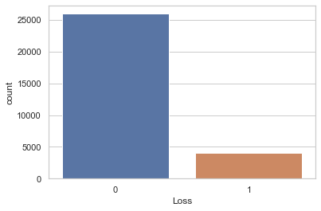

```python
sns.countplot(df['Loss'],label="Sum")
plt.show()
plt.savefig('count_plot')
```

```python
df.groupby('Loss').mean()
```

| Loss | Distance | HardBrakes | HardAccelerations | NightTime_Pct |
| --- | --- | --- | --- | --- |
| 0 | 13440.090762 | 167.442951 | 104.528130 | 0.029429 |
| 1 | 14757.022823 | 170.241131 | 138.251054 | 0.031782 |

```python
df.groupby('VehicleType').mean()
```

| VehicleType | Distance | HardBrakes | HardAccelerations | NightTime_Pct | Loss |
| --- | --- | --- | --- | --- | --- |
| Car | 13671.416951 | 171.331756 | 114.950468 | 0.029100 | 0.124381 |
| Minivan | 13509.717105 | 162.078947 | 105.438816 | 0.029173 | 0.101974 |
| SUV | 13654.422618 | 169.801688 | 109.119389 | 0.030422 | 0.146724 |
| Truck | 13565.934211 | 164.635350 | 104.997570 | 0.029886 | 0.138367 |

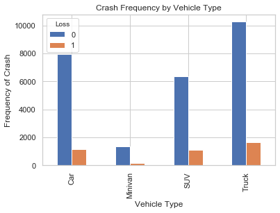

```python
pd.crosstab(df.VehicleType,df.Loss).plot(kind='bar')
plt.title('Crash Frequency by Vehicle Type')
plt.xlabel('Vehicle Type')
plt.ylabel('Frequency of Crash')
plt.savefig('crash_fre_vehicletype')
```

# Drop rows with missing values

```python
df.isnull().mean()
```

```
Distance             0.0
HardBrakes           0.0
HardAccelerations    0.0
NightTime_Pct        0.0
VehicleType          0.0
Loss                 0.0
dtype: float64
```

```python
df.dropna(subset=df.columns[df.isnull().mean()!=0], how='any', axis=0, inplace=True)
df.shape
```

```
(30000, 6)
```

# One-Hot encode Vehicle Type

```python
#ohe_fields=['VehicleType']

# One-Hot encode a couple of variables
#df_ohe = pd.get_dummies(df,columns=ohe_fields)

# Get the one-hot variable names
#ohe_feature_names = pd.get_dummies(df[ohe_fields],columns=ohe_fields).columns.tolist()
df=pd.get_dummies(df,drop_first=False)
columns=df.columns
df.info()
```

```
<class 'pandas.core.frame.DataFrame'>
Int64Index: 30000 entries, 0 to 29999
Data columns (total 9 columns):
Distance               30000 non-null int64
HardBrakes             30000 non-null int64
HardAccelerations      30000 non-null int64
NightTime_Pct          30000 non-null float64
Loss                   30000 non-null int64
VehicleType_Car        30000 non-null uint8
VehicleType_Minivan    30000 non-null uint8
VehicleType_SUV        30000 non-null uint8
VehicleType_Truck      30000 non-null uint8
dtypes: float64(1), int64(4), uint8(4)
memory usage: 1.5 MB
```

```python
X_train, X_test, y_train, y_test = train_test_split(X,y,test_size=0.3, random_state=21, stratify=y)
```

# Oversampling

```python
# example of random oversampling to balance the class distribution
y = df["Loss"]
X = df.drop(["Loss"], axis=1)
from collections import Counter
from sklearn.datasets import make_classification
from imblearn.over_sampling import RandomOverSampler
# define dataset
X, y = make_classification(n_samples=3000, weights=[0.99], flip_y=0)
# summarize class distribution
print(Counter(y))
# define oversampling strategy
oversample = RandomOverSampler(sampling_strategy='minority')
# fit and apply the transform
X_over, y_over = oversample.fit_resample(X, y)
# summarize class distribution
print(Counter(y_over))
X
```

```
Counter({0: 2970, 1: 30})
Counter({0: 2970, 1: 2970})
```

[output not shown]

# Random Forest Balanced Class

```python
# class balanced random forest for imbalanced classification
from numpy import mean
from sklearn.datasets import make_classification
from sklearn.model_selection import cross_val_score
from sklearn.model_selection import RepeatedStratifiedKFold
from sklearn.ensemble import RandomForestClassifier
# generate dataset
X, y = make_classification(n_samples=3000, n_features=2, n_redundant=0,
	n_clusters_per_class=1, weights=[0.99], flip_y=0, random_state=4)
# define model
model = RandomForestClassifier(n_estimators=100, class_weight='balanced')
model.fit(X_train, y_train)
# define evaluation procedure
cv = RepeatedStratifiedKFold(n_splits=10, n_repeats=3, random_state=1)
# evaluate model
scores = cross_validate(model, X, y, scoring=('roc_auc','accuracy', 'precision_macro', 'recall_macro' , 'f1_weighted'), cv=cv, n_jobs=-1)
# summarize performances
sorted(scores.keys())
forest_fit_time = scores['fit_time'].mean()
forest_score_time = scores['score_time'].mean()
forest_accuracy = scores['test_accuracy'].mean()
forest_precision = scores['test_precision_macro'].mean()
forest_recall = scores['test_recall_macro'].mean()
forest_f1 = scores['test_f1_weighted'].mean()
forest_roc = scores['test_roc_auc'].mean()
```

```python
models_initial = pd.DataFrame({
    'Model'       : ['Random Forest'],
    'Fitting time': [forest_fit_time],
    'Scoring time': [forest_score_time],
    'Accuracy'    : [forest_accuracy],
    'Precision'   : [forest_precision],
    'Recall'      : [forest_recall],
    'F1_score'    : [forest_f1,],
    'AUC_ROC'     : [forest_roc,],
    }, columns = ['Model', 'Fitting time', 'Scoring time', 'Accuracy', 'Precision', 'Recall', 'F1_score', 'AUC_ROC'])

models_initial.sort_values(by='Accuracy', ascending=False)
```

|  | Model | Fitting time | Scoring time | Accuracy | Precision | Recall | F1_score | AUC_ROC |
| --- | --- | --- | --- | --- | --- | --- | --- | --- |
| 0 | Random Forest | 0.157272 | 0.060905 | 0.999333 | 0.999664 | 0.966667 | 0.999267 | 0.983109 |

```python
#forest = RandomForestClassifier()
y_pred_test = model.predict(X_test)
accuracy_score(y_test, y_pred_test)
# View confusion matrix for test data and predictions
```

```
0.99
```

```
[[891   0]
 [  9   0]]
```

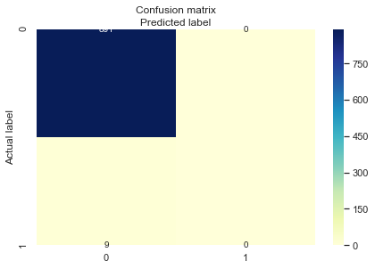

```python
from sklearn.metrics import confusion_matrix
conf_matrix = confusion_matrix(y_test,y_pred_test)
print(conf_matrix)

class_names=[0,1] # name  of classes
fig, ax = plt.subplots()
tick_marks = np.arange(len(class_names))
plt.xticks(tick_marks, class_names)
plt.yticks(tick_marks, class_names)
# create heatmap
sns.heatmap(pd.DataFrame(conf_matrix), annot=True, cmap="YlGnBu" ,fmt='g')
ax.xaxis.set_label_position("top")
plt.tight_layout()
plt.title('Confusion matrix', y=1.1)
plt.ylabel('Actual label')
plt.xlabel('Predicted label')
```

```
Variable: Loss                 Importance: 0.29
Variable: Distance             Importance: 0.04
Variable: HardAccelerations    Importance: 0.04
Variable: NightTime_Pct        Importance: 0.04
Variable: VehicleType_Car      Importance: 0.04
Variable: VehicleType_Truck    Importance: 0.04
Variable: VehicleType_Minivan  Importance: 0.03
Variable: HardBrakes           Importance: 0.02
Variable: VehicleType_SUV      Importance: 0.02
```

[figure not shown]

```python
feature_list = list(df.columns)
importances = list(model.feature_importances_)
feature_importances = [(feature, round(importance, 2)) for feature, importance in zip(feature_list, importances)]
feature_importances = sorted(feature_importances, key = lambda x: x[1], reverse = True)
[print('Variable: {:20} Importance: {}'.format(*pair)) for pair in feature_importances];
# Set the style
plt.style.use('classic')
# list of x locations for plotting
x_values = list(range(len(importances)))
# Make a bar chart
plt.bar(x_values, importances, orientation = 'vertical')
# Tick labels for x axis
plt.xticks(x_values, feature_list, rotation='vertical')
# Axis labels and title
plt.ylabel('Importance'); plt.xlabel('Variable'); plt.title('Variable Importances');
```

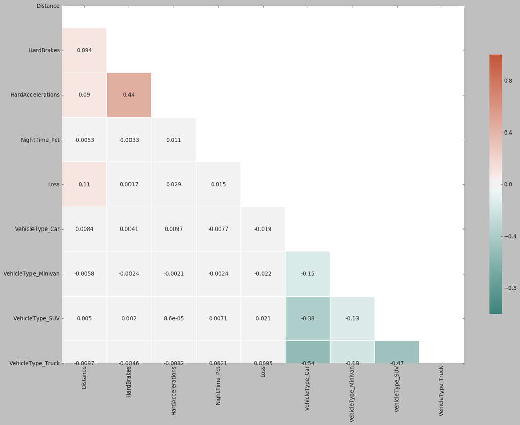

```python
correlation = df.corr()

mask = np.zeros_like(correlation, dtype=np.bool)
mask[np.triu_indices_from(mask)] = True

f, ax = plt.subplots(figsize=(20, 20))

cmap = sns.diverging_palette(180, 20, as_cmap=True)
sns.heatmap(correlation, mask=mask, cmap=cmap, vmax=1, vmin =-1, center=0,
            square=True, linewidths=.5, cbar_kws={"shrink": .5}, annot=True)

plt.show()
```

```python
# example of evaluating a decision tree with random oversampling

# define dataset
X, y = make_classification(n_samples=3000, weights=[0.99], flip_y=0)
print(X)
# define pipeline
steps = [('over', RandomOverSampler()), ('model', DecisionTreeClassifier())]
pipeline = Pipeline(steps=steps)
# evaluate pipeline
cv = RepeatedStratifiedKFold(n_splits=10, n_repeats=3, random_state=1)
scores = cross_val_score(pipeline, X, y, scoring='f1_micro', cv=cv, n_jobs=-1)
score = mean(scores)
pca = PCA()
smt = SMOTE(random_state=42)
knn = KNN()
pipeline = Pipeline([('smt', smt), ('pca', pca), ('knn', knn)])
X_train, X_test, y_train, y_test = tts(X, y, random_state=42)
pipeline.fit(X_train, y_train)

y_hat = pipeline.predict(X_test)
print(classification_report(y_test, y_hat))
print('F1 Score: %.3f' % score)
```

```
[[ 0.4680252   0.91475516 -0.4742441  ... -0.52621451 -0.32442569
   0.56054837]
 [-0.781434   -0.42373228 -1.03631208 ... -0.16409688  0.38844994
   0.68506378]
 [ 0.61210862  0.88491116 -0.10430307 ...  0.81602145  0.86970867
   0.29824225]
 ...
 [ 1.13409938  0.92900278  0.98378782 ... -0.17997573 -0.10780743
   0.73050853]
 [-0.32297473 -0.07913522 -0.58734288 ...  0.72285726  0.70420248
  -0.72031936]
 [-0.47763392 -0.324314   -0.5252216  ...  0.13934566 -1.22404683
   0.76783774]]
              precision    recall  f1-score   support

           0       0.99      0.93      0.96       744
           1       0.04      0.33      0.06         6

    accuracy                           0.92       750
   macro avg       0.51      0.63      0.51       750
weighted avg       0.99      0.92      0.95       750

F1 Score: 0.990
```

# Logistic Regression

```
Feature: 0, Score: 0.93179
Feature: 1, Score: 0.22327
Feature: 2, Score: 1.70283
Feature: 3, Score: 0.08801
Feature: 4, Score: 0.37080
Feature: 5, Score: -0.15728
Feature: 6, Score: -0.12691
Feature: 7, Score: -0.59976
Feature: 8, Score: 0.30348
Feature: 9, Score: -0.14843
Feature: 10, Score: 0.10839
Feature: 11, Score: 0.03958
Feature: 12, Score: -0.15194
Feature: 13, Score: 0.02042
Feature: 14, Score: -0.02942
Feature: 15, Score: 0.14174
Feature: 16, Score: -0.00408
Feature: 17, Score: -0.07385
Feature: 18, Score: -0.12663
Feature: 19, Score: -0.12315
```

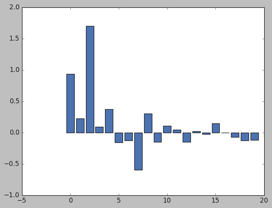

```
0.9893333333333333
```

```python
from sklearn.linear_model import LinearRegression
from matplotlib import pyplot
LR = LogisticRegression()
LR = LR.fit(X,y)
# get importance
importance = LR.coef_[0]
# summarize feature importance
for i,v in enumerate(importance):
	print('Feature: %0d, Score: %.5f' % (i,v))
# plot feature importance
pyplot.bar([x for x in range(len(importance))], importance)
pyplot.show()
LR.score(X,y)
```

# Predict y

```python
y_pred = LR.predict(X_test)
print('Accuracy of logistic regression classified on test set:{:.2f}'.format(LR.score(X_test,y_test)))
```

```
Accuracy of logistic regression classified on test set:0.99
```

# Confusion Matrix

```python
from sklearn.metrics import confusion_matrix
conf_matrix = confusion_matrix(y_test, y_hat)
print(conf_matrix)
```

```
[[690  54]
 [  4   2]]
```

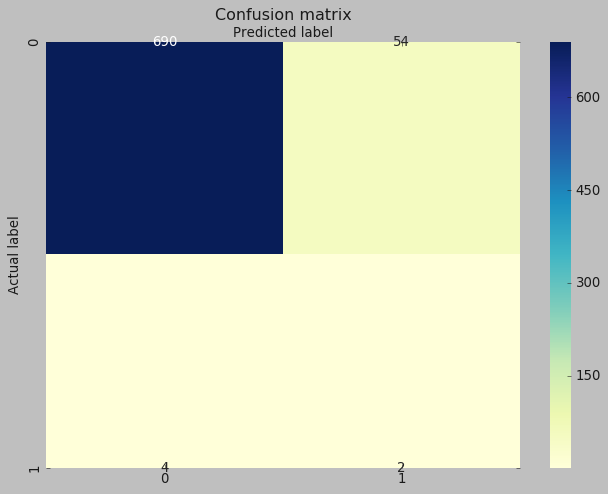

```python
class_names=[0,1] # name  of classes
fig, ax = plt.subplots()
tick_marks = np.arange(len(class_names))
plt.xticks(tick_marks, class_names)
plt.yticks(tick_marks, class_names)
# create heatmap
sns.heatmap(pd.DataFrame(conf_matrix), annot=True, cmap="YlGnBu" ,fmt='g')
ax.xaxis.set_label_position("top")
plt.tight_layout()
plt.title('Confusion matrix', y=1.1)
plt.ylabel('Actual label')
plt.xlabel('Predicted label')
```

# LR Coefficients

```python
LR.fit(X / np.std(X, 0), y)
print(LR.coef_)
pd.DataFrame(zip(X, np.transpose(LR.coef_)))
```

```
[[ 0.89741176  0.04218877  1.61875709  0.08750966  0.36846661 -0.16049341
  -0.12901791 -0.78378382  0.30245103 -0.14975055  0.10978481  0.0381182
  -0.15121545  0.01967371 -0.03086226  0.14412766 -0.00303152 -0.0756906
  -0.12782761 -0.12232646]]
```

[output not shown]

# Correlation Heat Map

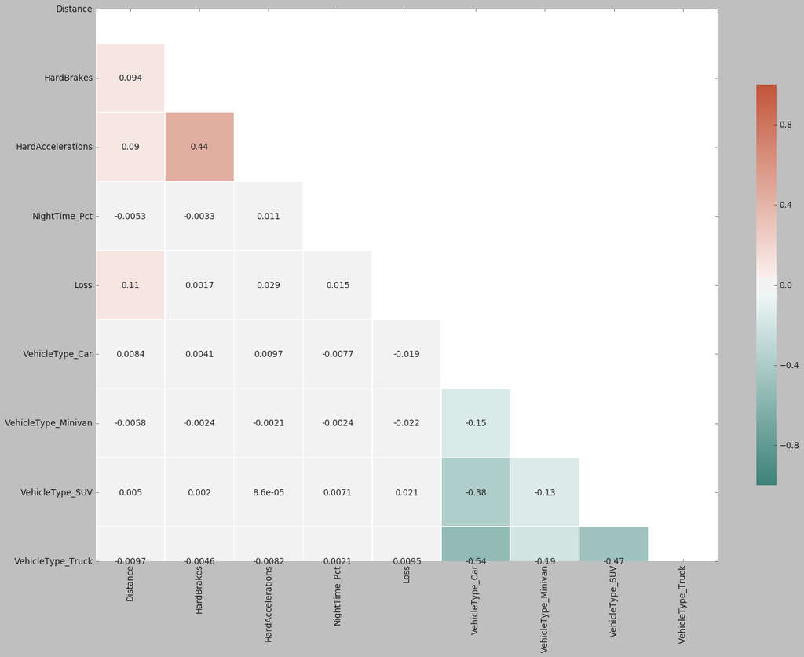

```python
correlation = df.corr()

mask = np.zeros_like(correlation, dtype=np.bool)
mask[np.triu_indices_from(mask)] = True

f, ax = plt.subplots(figsize=(20, 20))

cmap = sns.diverging_palette(180, 20, as_cmap=True)
sns.heatmap(correlation, mask=mask, cmap=cmap, vmax=1, vmin =-1, center=0,
            square=True, linewidths=.5, cbar_kws={"shrink": .5}, annot=True)

plt.show()
```

# ROC and AUC

[figure not shown]

```python
LR_roc_auc = roc_auc_score(y_test, LR.predict(X_test))
fpr, tpr, thresholds = roc_curve(y_test, LR.predict_proba(X_test)[:,1])
plt.figure()
plt.plot(fpr,tpr, label='Logistic Regression (area = %0.2f)' %
        LR_roc_auc)
plt.plot([0,1], [0,1], 'r--')
plt.xlim([0.0, 1.0])
plt.ylim([0.0, 1.05])
plt.xlabel ('False Positive Rate')
plt.ylabel ('True Positive Rate')
plt.title ('Reciever Operating Characteristic')
plt.legend(loc="lower right")
plt.savefig('Log_ROC')
plt.show()
```

# Analysis

[output not shown]

# Data Set Enhancement

[output not shown]